# Perceptual decision making, motion and hand movements

```r
# working directory
knitr::opts_knit$set(root.dir = '~/Projects/CompelledMovements/data')
```

based on the paradigm and analysis by Stanford et al 2010 (compelled saccades), we tested observers responses to rapidly moving stimuli and determine how fast a direction change (available information about the direction) can be intergrated in visual processing

We run 3 different experiments, where presentation of the stimuli differ in terms of predictability.

All experiments are analysed based on the design used by stanford and colleagues.

Analysis 1 - % correct answers as a function of gap time 2 - Reaction times as a function of gap time 3 - Frequencies of ePTs in correct/incorrect answers 4 - % correct answers as a function of ePT 5 - Frequencies of reaction times for correct/incorrect answers at different gaps

What this notebook should do:

Plot the results

```r
# step one - prepare functions

# get nd time as minimum reaction time
get_nd_time <- function(data){
  # remove negative values
  rea_times <- data#[-which(data<0)]

  return(as.numeric(quantile(rea_times, 0.25)))
}

# define correct and incorrect answers
label_resp <- function(direction, response){
  label_vec <- vector()
  cnt <- 1
  for (resp in response){
    label <- NA
    if (resp == 'v'){
      if  (direction[cnt] == '-'){
      label <- 1
      }
      else{
        label <- 0
        }
      }
    if (resp == 'n'){
      if (direction[cnt] == '+'){
        label <- 1
      }
      else{
      label <- 0
      }
    }
    label_vec[cnt] <- label
    cnt <- cnt+1
  }
  return(label_vec)
}

# prepare a dataset with % correct for bins of gap times
binned_data <- function(data_time, data_resp, start, stop, step){
  steps_dis = seq(start,stop,step)
  start_dis = start - step
  outmat = matrix(nrow=length(steps_dis), ncol = 2)

  for (step in steps_dis){
    idx_time <- which(data_time>=start_dis & data_time<=step)
    samples <- length(idx_time)
    percentage <- sum(data_resp[idx_time],na.rm=TRUE)/samples
    outmat[which(steps_dis == step),1] <- step
    outmat[which(steps_dis == step),2] <- percentage
    start_dis = step
    }
  return(outmat)
}
```

Experiment 1 - variation in distance ball-goal In this experiment there is not such a thing as “gap time” We can model the flight time alternatively or the reaction time

```r
CoMo1_data   <- read.table("CoMo1ck1.txt",header = TRUE)
CoMo1_design <- read.table("CoMo1desck1.txt",header = TRUE)

id_rm        <- which(CoMo1_data$response != 'n' & CoMo1_data$response != 'v')

CoMo1_data   <- CoMo1_data[-id_rm,]
CoMo1_design <- CoMo1_design[-id_rm,]

CoMo1_data$correct <- label_resp(CoMo1_design$direction,CoMo1_data$response)
NP           <- get_nd_time(CoMo1_data$t_response)

# t_response is relative to the onset of the ball motion
CoMo1_data$ePT     <- CoMo1_data$t_response - NP

# check distribution of ePT
summary(CoMo1_data$t_response)
```

```
##      Min.   1st Qu.    Median      Mean   3rd Qu.      Max.
## 0.0007537 0.0488500 0.0889300 0.1056000 0.1468000 0.4963000
```

```r
#ana 1 - correct answers as a function of gap time (not possible here, using goal distance)
CoMo1_dis <- binned_data(CoMo1_design$distance,CoMo1_data$correct,1,8,1)


#ana 2 - reaction times as a function of distance
#build a model, linear regression
#Null model - explained by mean
aov_CoMo1_rea_times <- aov(CoMo1_data$t_response ~ CoMo1_design$distance)
summary(aov_CoMo1_rea_times)
```

```
##                        Df Sum Sq Mean Sq F value Pr(>F)
## CoMo1_design$distance   1 0.9637  0.9637     227 <2e-16 ***
## Residuals             553 2.3481  0.0042
## ---
## Signif. codes:  0 '***' 0.001 '**' 0.01 '*' 0.05 '.' 0.1 ' ' 1
```

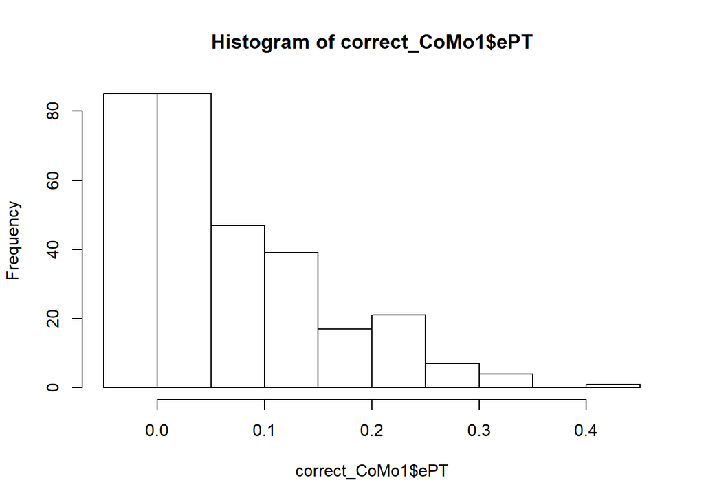

```r
#ana 3 - Frequencies of ePTs in correct/incorrect answers
correct_CoMo1   <- CoMo1_data[which(CoMo1_data$correct==1),]
incorrect_CoMo1 <- CoMo1_data[which(CoMo1_data$correct==0),]

corr_his   <- hist(correct_CoMo1$ePT)
```

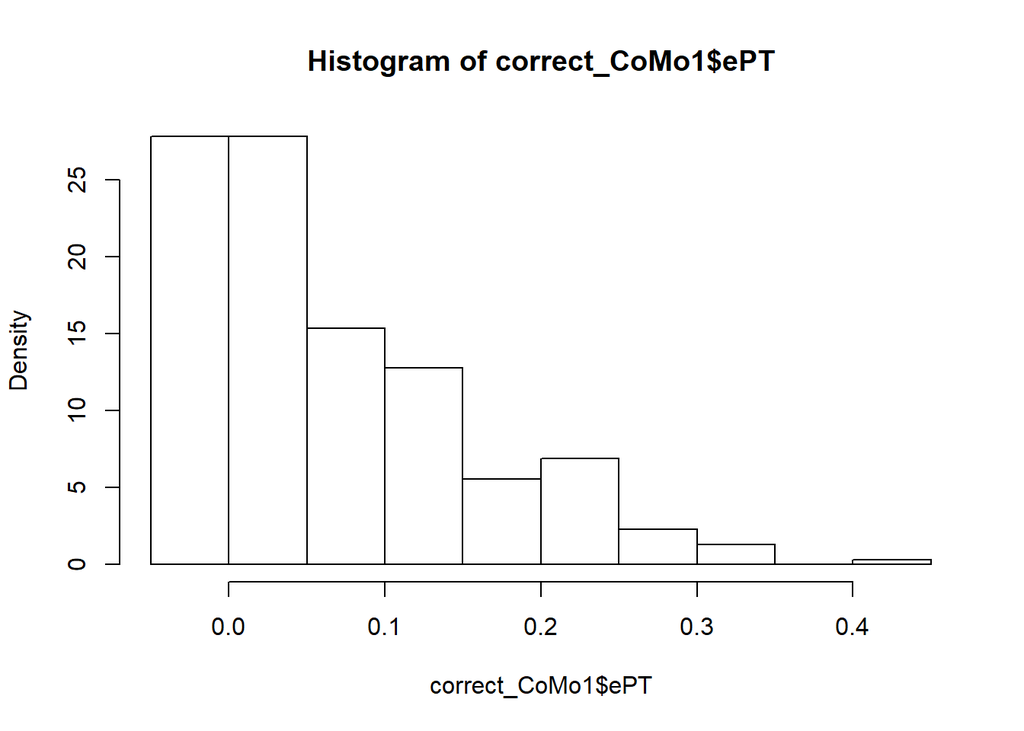

```r
corr_his$density = corr_his$counts/sum(corr_his$counts)*100
plot(corr_his,freq=FALSE)
```

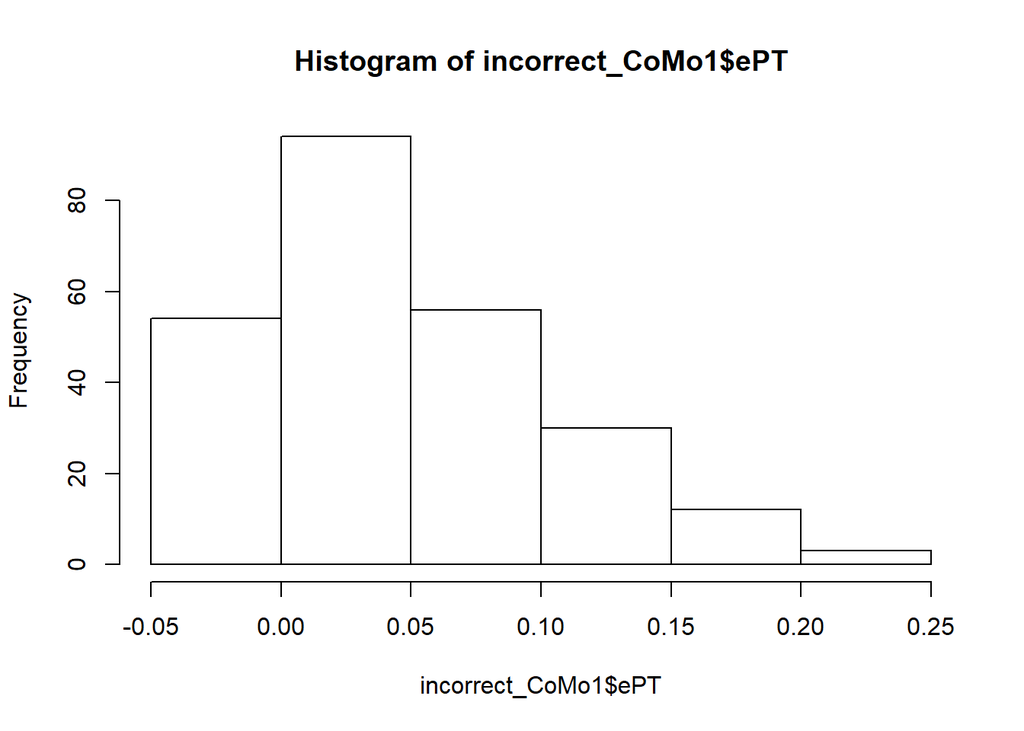

```r
incorr_his <- hist(incorrect_CoMo1$ePT)
```

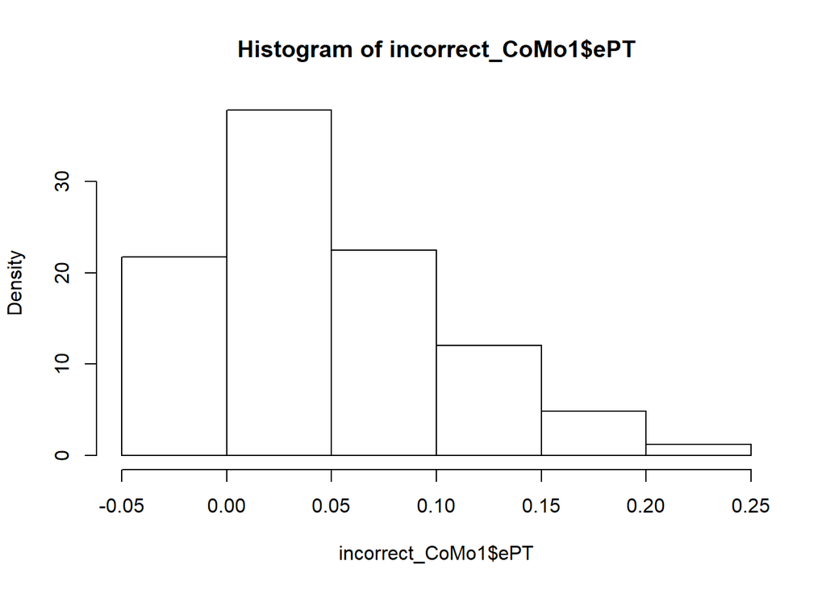

```r
incorr_his$density = incorr_his$counts/sum(incorr_his$counts)*100
plot(incorr_his,freq=FALSE)
```

```r
#ana 4 - % correct answers as a function of ePT
CoMo1_bin <- binned_data(CoMo1_data$ePT,CoMo1_data$correct,-0.1,0.4,0.05)

#ana 5 - left out so far
```

Experiment 2 - sudden change of direction

```r
CoMo2_data   <- read.table("CoMo2ck0.txt",header = TRUE)
CoMo2_design <- read.table("CoMo2desck0.txt",header = TRUE)

id_rm        <- which(CoMo2_data$response != 'n' & CoMo2_data$response != 'v')

CoMo2_data   <- CoMo2_data[-id_rm,]
CoMo2_design <- CoMo2_design[-id_rm,]

CoMo2_data$correct <- label_resp(CoMo2_data$rev_sign,CoMo2_data$response)
NP          <- get_nd_time(CoMo2_data$t_response)

CoMo2_data$t_change<- CoMo2_data$t_change*CoMo2_design$change

# t_response is relative to the onset of the ball motion
CoMo2_data$ePT     <- (CoMo2_data$t_response+CoMo2_data$t_ball) - CoMo2_data$t_change - NP

# check distribution of ePT
summary(CoMo2_data$t_change)
```

```
##    Min. 1st Qu.  Median    Mean 3rd Qu.    Max.
##  0.0000  0.0000  0.0000  0.3065  0.5700  9.8230
```

```r
#ana 1 - correct answers as a function of gap time (not possible here, using goal distance)
CoMo2_dis <- binned_data(CoMo2_data$t_change,CoMo2_data$correct,0,1.5,0.1)


#ana 2 - reaction times as a function of distance
#build a model, linear regression
#Null model - explained by mean
aov_CoMo2_rea_times <- aov(CoMo2_data$t_response ~ CoMo2_design$change_loc)
summary(aov_CoMo2_rea_times)
```

```
##                          Df Sum Sq  Mean Sq F value Pr(>F)
## CoMo2_design$change_loc   1  0.000 0.000406   0.057  0.812
## Residuals               635  4.531 0.007135
```

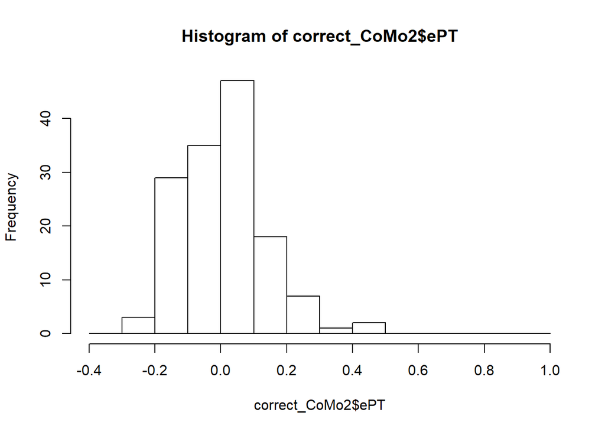

```r
#ana 3 - Frequencies of ePTs in correct/incorrect answers
correct_CoMo2   <- CoMo2_data[which(CoMo2_data$correct==1),]
incorrect_CoMo2 <- CoMo2_data[which(CoMo2_data$correct==0),]
incorrect_CoMo2 <- incorrect_CoMo2[which(incorrect_CoMo2$ePT<1),]

corr_his2   <- hist(correct_CoMo2$ePT,breaks = seq(-0.4,1,0.1))
```

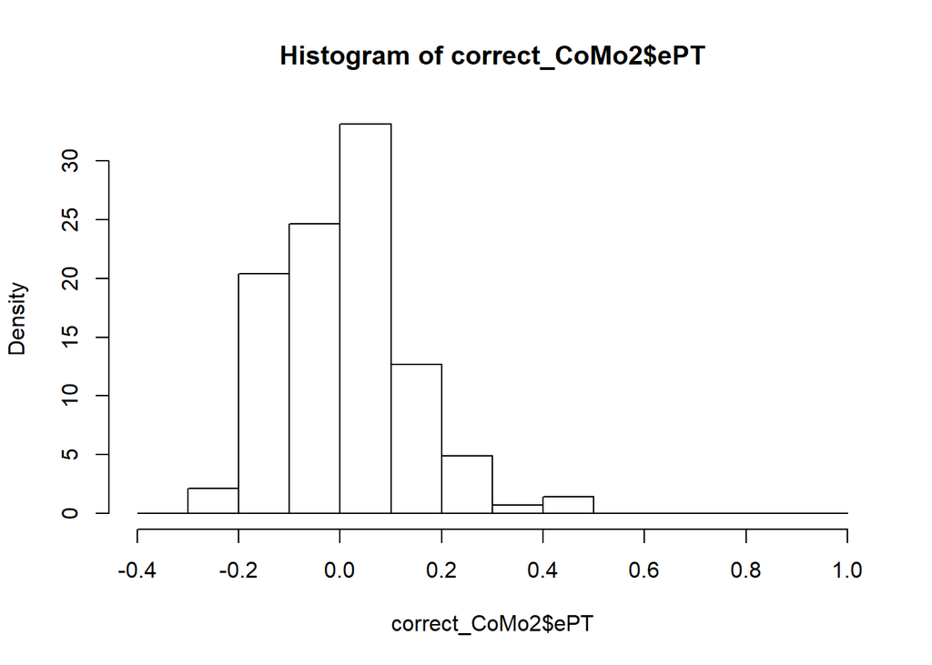

```r
corr_his2$density = corr_his2$counts/sum(corr_his2$counts)*100
plot(corr_his2,freq=FALSE)
```

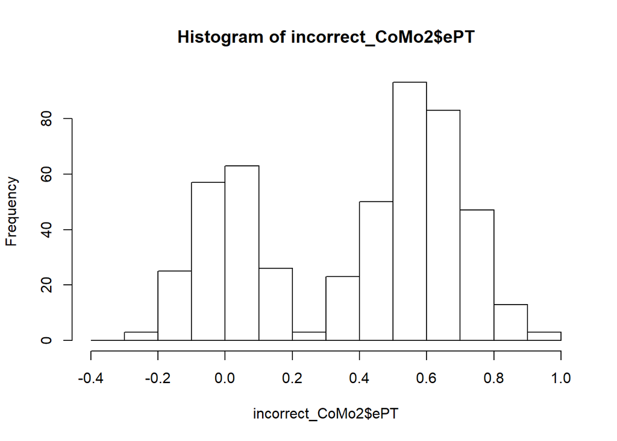

```r
incorr_his2 <- hist(incorrect_CoMo2$ePT, breaks = seq(-0.4,1,0.1))
```

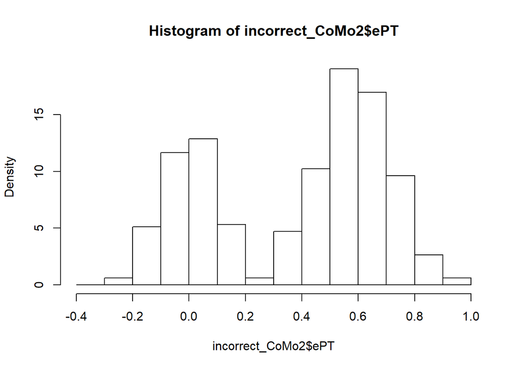

```r
incorr_his2$density = incorr_his2$counts/sum(incorr_his2$counts)*100
plot(incorr_his2,freq=FALSE)
```

```r
#ana 4 - % correct answers as a function of ePT
CoMo2_bin <- binned_data(CoMo2_data$ePT,CoMo2_data$correct,-0.3,0.6,0.1)

#ana 5 - left out so far
```

Experiment 3: direction suddenly

```r
CoMo3_data   <- read.table("CoMo3ck1.txt",header = TRUE)
CoMo3_design <- read.table("CoMo3desck1.txt",header = TRUE)

id_rm        <- which(CoMo3_data$response != 'n' & CoMo3_data$response != 'v')

CoMo3_data$correct <- label_resp(CoMo3_design$direction,CoMo3_data$response)
NP          <- get_nd_time(CoMo3_data$t_response)

# t_response is relative to the onset of the ball motion
CoMo3_data$ePT     <- CoMo3_data$t_response - (CoMo3_data$t_change-CoMo3_data$t_ball) - NP

# check distribution of ePT
summary(CoMo3_data$t_change)
```

```
##    Min. 1st Qu.  Median    Mean 3rd Qu.    Max.
##  0.3029  0.5031  0.5863  0.6306  0.6698  7.1840
```

```r
#ana 1 - correct answers as a function of gap time (not possible here, using goal distance)
CoMo3_dis <- binned_data(CoMo3_data$t_change,CoMo3_data$correct,0.3,1.0,0.1)


#ana 2 - reaction times as a function of distance
#build a model, linear regression
#Null model - explained by mean
aov_CoMo3_rea_times <- aov(CoMo3_data$t_response ~ CoMo3_design$change_loc)
summary(aov_CoMo3_rea_times)
```

```
##                          Df Sum Sq  Mean Sq F value Pr(>F)
## CoMo3_design$change_loc   1 0.0028 0.002821   0.469  0.494
## Residuals               318 1.9125 0.006014
```

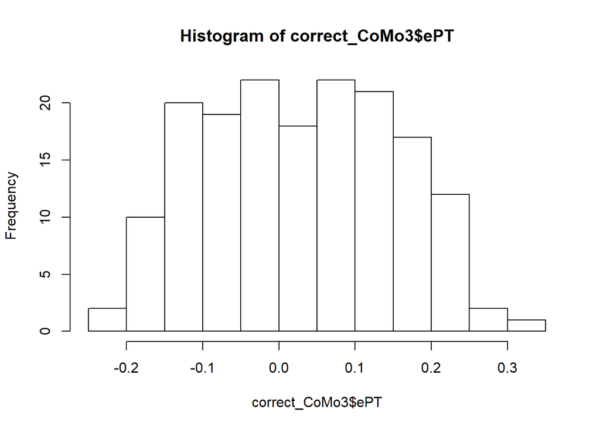

```r
#ana 3 - Frequencies of ePTs in correct/incorrect answers
correct_CoMo3   <- CoMo3_data[which(CoMo3_data$correct==1),]
incorrect_CoMo3 <- CoMo3_data[which(CoMo3_data$correct==0),]

corr_his3   <- hist(correct_CoMo3$ePT)
```

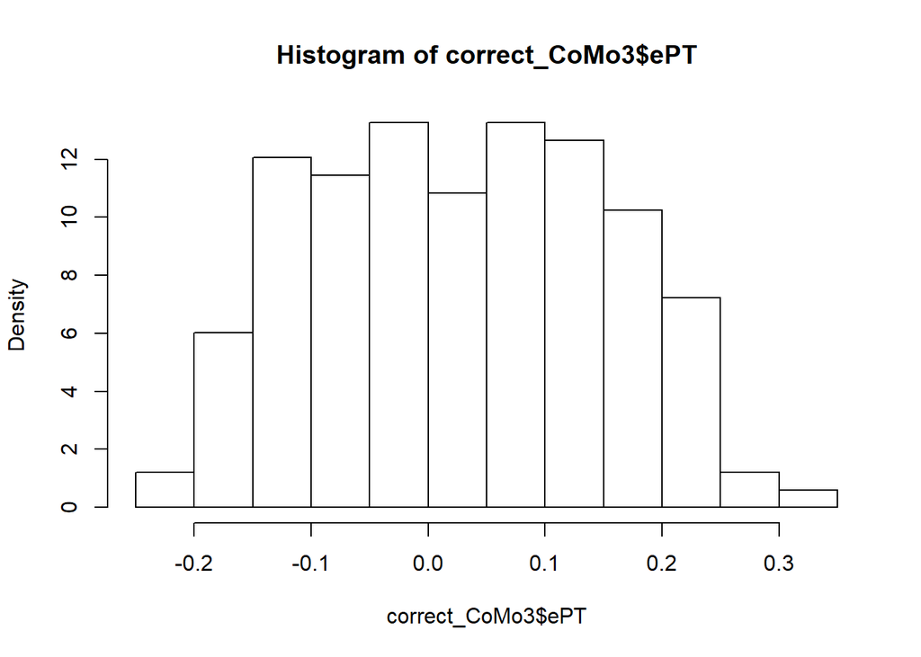

```r
corr_his3$density = corr_his3$counts/sum(corr_his3$counts)*100
plot(corr_his3,freq=FALSE)
```

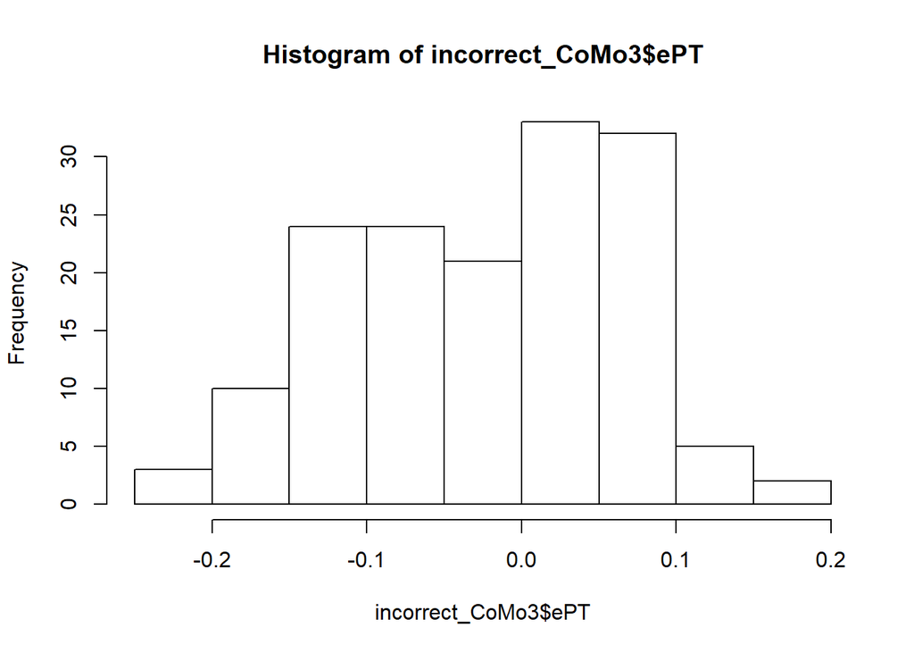

```r
incorr_his3 <- hist(incorrect_CoMo3$ePT)
```

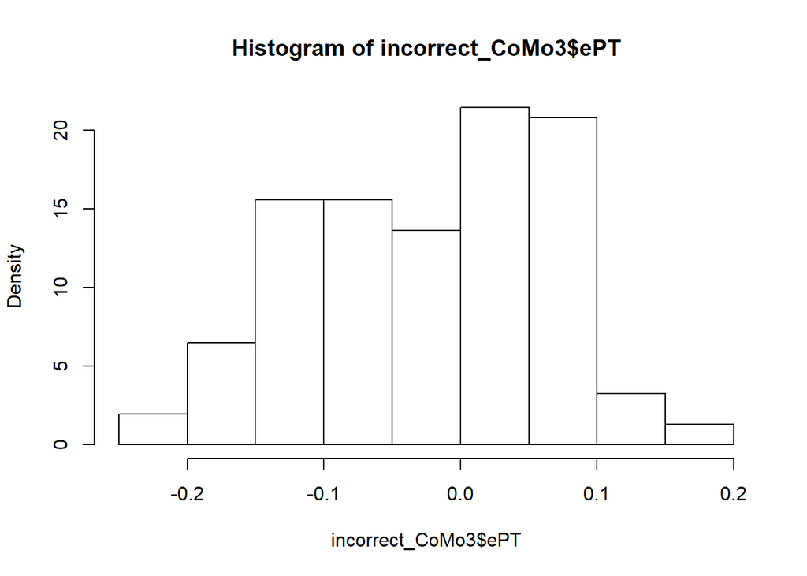

```r
incorr_his3$density = incorr_his3$counts/sum(incorr_his3$counts)*100
plot(incorr_his3,freq=FALSE)
```

```r
#ana 4 - % correct answers as a function of ePT
CoMo3_bin <- binned_data(CoMo3_data$ePT,CoMo3_data$correct,-0.3,0.3,0.1)

#ana 5 - left out so far
```